# Linear regression in R

Jeff Leek

## Dependencies

This document depends on the following packages:

```r
  library(devtools)
  library(Biobase)
  library(broom)
```

To install these packages you can use the code (or if you are compiling the document, remove the `eval=FALSE` from the chunk.)

```r
install.packages(c("devtools","broom"))
source("http://www.bioconductor.org/biocLite.R")
biocLite(c("Biobase"))
```

## Download the data

Here we are going to use some data from the paper [Detection of redundant fusion transcripts as biomarkers or disease-specific therapeutic targets in breast cancer.](http://www.ncbi.nlm.nih.gov/pubmed/22496456) that uses data from different normal human tissues (called the Illumina BodyMap data).

```r
con =url("http://bowtie-bio.sourceforge.net/recount/ExpressionSets/bodymap_eset.RData")
load(file=con)
close(con)
bm = bodymap.eset
pdata=pData(bm)
edata=as.data.frame(exprs(bm))
fdata = fData(bm)
ls()
```

```
## [1] "bm"           "bodymap.eset" "con"          "edata"
## [5] "fdata"        "pdata"        "tropical"
```

## Fit a simple linear regression

Here we regress the counts for the first gene on the age of the people from whom the tissue was drawn.

```r
edata = as.matrix(edata)
lm1 = lm(edata[1,] ~ pdata$age)
tidy(lm1)
```

```
##          term   estimate  std.error statistic      p.value
## 1 (Intercept) 2187.90554 402.998816  5.429062 8.884114e-05
## 2   pdata$age  -23.24999   6.390269 -3.638343 2.686225e-03
```

## Is fitting the line a good idea?

Visual diagnostics are often some of the most helpful

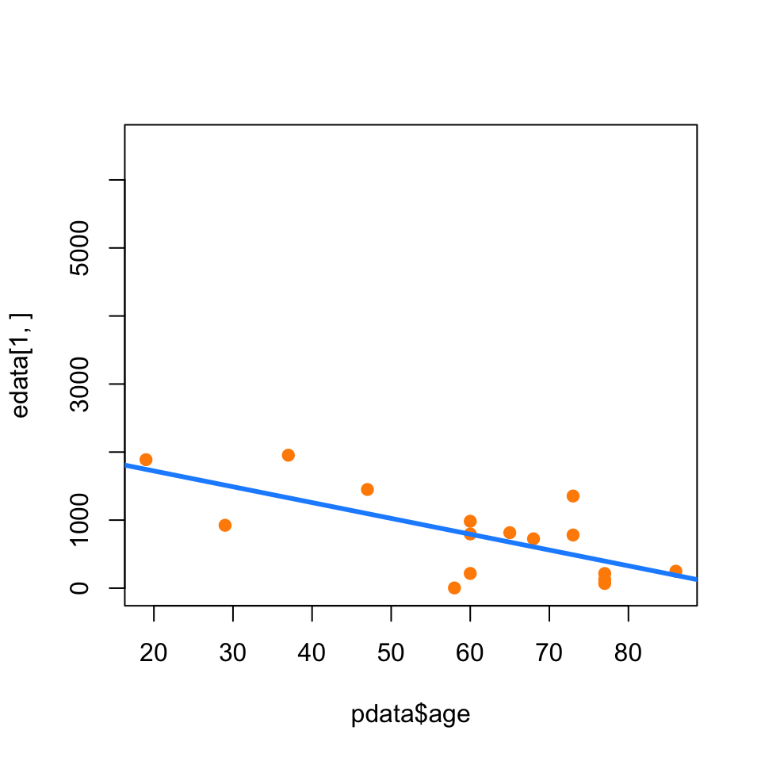

```r
plot(pdata$age,edata[1,], col=1)
abline(lm1$coeff[1],lm1$coeff[2], col=2,lwd=3)
```

## What about categorical variables?

```r
pdata$gender
```

```
##  [1] F    M    F    F    F    M    F    M    M    F    <NA> <NA> <NA> F
## [15] M    M    M    F    M
## Levels: F M
```

```r
table(pdata$gender)
```

```
##
## F M
## 8 8
```

## Visualize the difference between genders

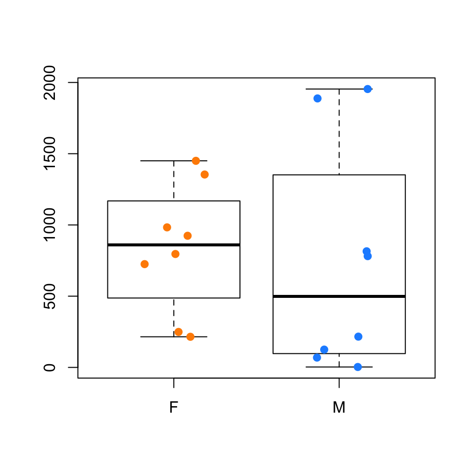

```r
boxplot(edata[1,] ~ pdata$gender)
points(edata[1,] ~ jitter(as.numeric(pdata$gender)),
       col=as.numeric(pdata$gender))
```

## “dummy” variables

```r
dummy_m = pdata$gender=="M"
dummy_m
```

```
##  [1] FALSE  TRUE FALSE FALSE FALSE  TRUE FALSE  TRUE  TRUE FALSE    NA
## [12]    NA    NA FALSE  TRUE  TRUE  TRUE FALSE  TRUE
```

```r
dummy_f = pdata$gender=="F"
dummy_f
```

```
##  [1]  TRUE FALSE  TRUE  TRUE  TRUE FALSE  TRUE FALSE FALSE  TRUE    NA
## [12]    NA    NA  TRUE FALSE FALSE FALSE  TRUE FALSE
```

## R’s modeling formulae do this for you automatically

```r
lm2 = lm(edata[1,] ~ pdata$gender)
tidy(lm2)
```

```
##            term estimate std.error  statistic     p.value
## 1   (Intercept)  837.000  228.8055  3.6581292 0.002582905
## 2 pdata$genderM -105.625  323.5798 -0.3264264 0.748930374
```

## Peaking “under the hood” of the variables used in the model

```r
mod2 = model.matrix(~pdata$gender)
mod2
```

```
##    (Intercept) pdata$genderM
## 1            1             0
## 2            1             1
## 3            1             0
## 4            1             0
## 5            1             0
## 6            1             1
## 7            1             0
## 8            1             1
## 9            1             1
## 10           1             0
## 14           1             0
## 15           1             1
## 16           1             1
## 17           1             1
## 18           1             0
## 19           1             1
## attr(,"assign")
## [1] 0 1
## attr(,"contrasts")
## attr(,"contrasts")$`pdata$gender`
## [1] "contr.treatment"
```

## Categorical variables with multiple levels

```r
table(pdata$tissue.type)
```

```
##
##          adipose          adrenal            brain           breast
##                1                1                1                1
##            colon            heart           kidney            liver
##                1                1                1                1
##             lung        lymphnode          mixture            ovary
##                1                1                3                1
##         prostate  skeletal_muscle           testes          thyroid
##                1                1                1                1
## white_blood_cell
##                1
```

```r
pdata$tissue.type == "adipose"
```

```
##  [1]  TRUE FALSE FALSE FALSE FALSE FALSE FALSE FALSE FALSE FALSE FALSE
## [12] FALSE FALSE FALSE FALSE FALSE FALSE FALSE FALSE
```

```r
pdata$tissue.type == "adrenal"
```

```
##  [1] FALSE  TRUE FALSE FALSE FALSE FALSE FALSE FALSE FALSE FALSE FALSE
## [12] FALSE FALSE FALSE FALSE FALSE FALSE FALSE FALSE
```

## This leads to multiple coefficients for one variable

```r
tidy(lm(edata[1,] ~ pdata$tissue.type ))
```

```
##                                 term  estimate std.error   statistic
## 1                        (Intercept)  1354.000  1017.983  1.33008119
## 2           pdata$tissue.typeadrenal -1138.000  1439.645 -0.79047247
## 3             pdata$tissue.typebrain -1139.000  1439.645 -0.79116709
## 4            pdata$tissue.typebreast  -430.000  1439.645 -0.29868468
## 5             pdata$tissue.typecolon  -629.000  1439.645 -0.43691317
## 6             pdata$tissue.typeheart -1229.000  1439.645 -0.85368248
## 7            pdata$tissue.typekidney  -558.000  1439.645 -0.38759547
## 8             pdata$tissue.typeliver   600.000  1439.645  0.41676932
## 9              pdata$tissue.typelung  -539.000  1439.645 -0.37439777
## 10        pdata$tissue.typelymphnode -1105.000  1439.645 -0.76755016
## 11          pdata$tissue.typemixture  4043.333  1175.465  3.43977205
## 12            pdata$tissue.typeovary    96.000  1439.645  0.06668309
## 13         pdata$tissue.typeprostate  -573.000  1439.645 -0.39801470
## 14  pdata$tissue.typeskeletal_muscle -1285.000  1439.645 -0.89258095
```

[output cut: 21 more lines]

## Adjusting for variables

```r
lm3 = lm(edata[1,] ~ pdata$age + pdata$gender)
tidy(lm3)
```

```
##            term  estimate  std.error  statistic     p.value
## 1   (Intercept) 2331.5814 438.181127  5.3210448 0.000138739
## 2     pdata$age  -23.9133   6.488058 -3.6857414 0.002743642
## 3 pdata$genderM -207.2565 236.430512 -0.8766066 0.396610372
```

## Interactions (careful!)

You can add interaction terms, but there are a couple of things to keep in mind:

- Interpretation can be challenging
- You should always also include main effects
- Interactions in genomics data are in general hard to detect, and can be fraught for example in gene by environment interactions, the interaction term only tells you that there may be an association, but there are lots of reasons for this statistical association that aren’t biological interaction.

```r
lm4 = lm(edata[1,] ~ pdata$age*pdata$gender)
tidy(lm4)
```

```
##                      term   estimate  std.error statistic    p.value
## 1             (Intercept) 1679.37818 610.165662  2.752332 0.01752641
## 2               pdata$age  -13.47805   9.425164 -1.430007 0.17823223
## 3           pdata$genderM  912.51047 793.378850  1.150157 0.27248454
## 4 pdata$age:pdata$genderM  -18.46210  12.536549 -1.472662 0.16658057
```

## A few things to be aware of

Outliers can have a big impact on the regression, depending on where they land. Here there isn’t much impact

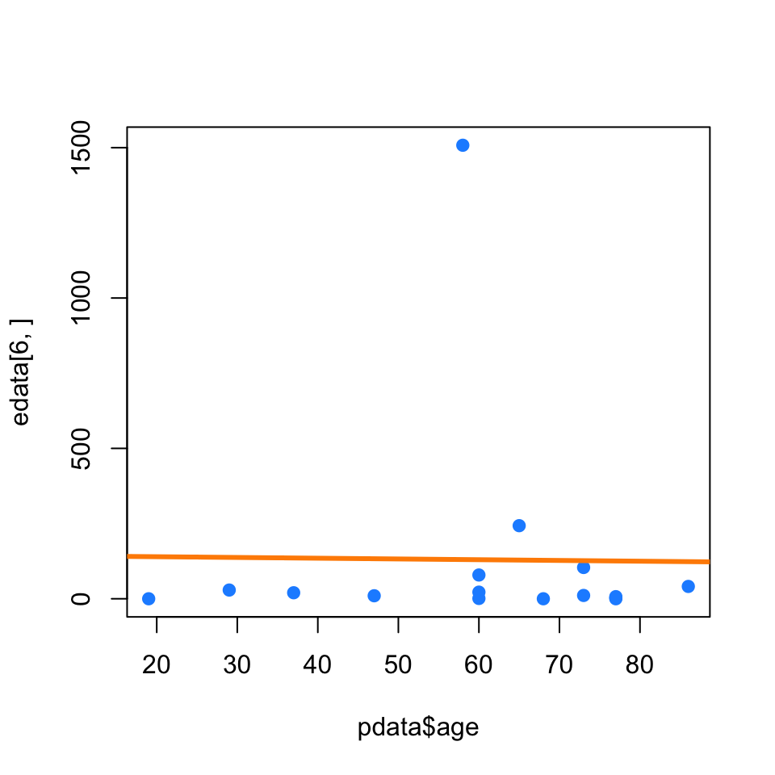

```r
lm4 = lm(edata[6,] ~ pdata$age)
plot(pdata$age,edata[6,],col=2)
abline(lm4,col=1,lwd=3)
```

But in this case there is a huge impact

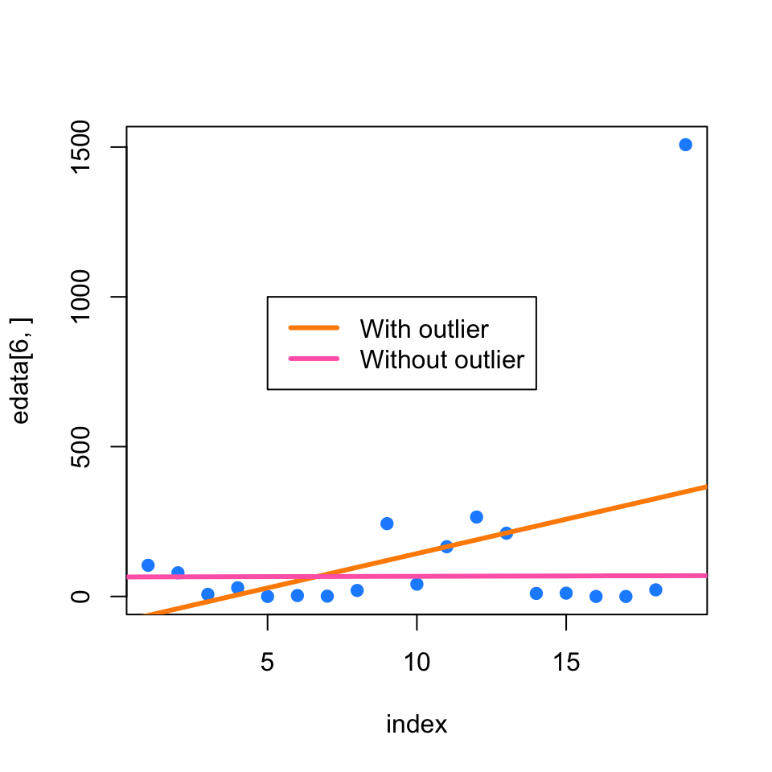

```r
index = 1:19
lm5 = lm(edata[6,] ~ index)
plot(index,edata[6,],col=2)
abline(lm5,col=1,lwd=3)

lm6 = lm(edata[6,-19] ~ index[-19])
abline(lm6,col=3,lwd=3)

legend(5,1000,c("With outlier","Without outlier"),col=c(1,3),lwd=3)
```

In general you’d like your residuals to looks symmetrically (e.g. approximately Normally) distributed but they aren’t here. Outliers in the residuals aren’t great either.

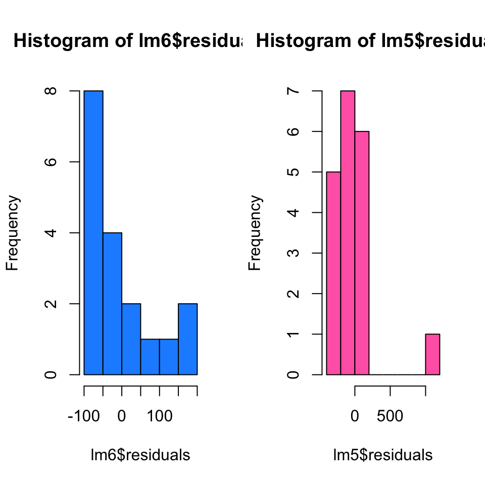

```r
par(mfrow=c(1,2))
hist(lm6$residuals,col=2)
hist(lm5$residuals,col=3)
```

Data transforms are often applied before regression and the residuals look a little better here.

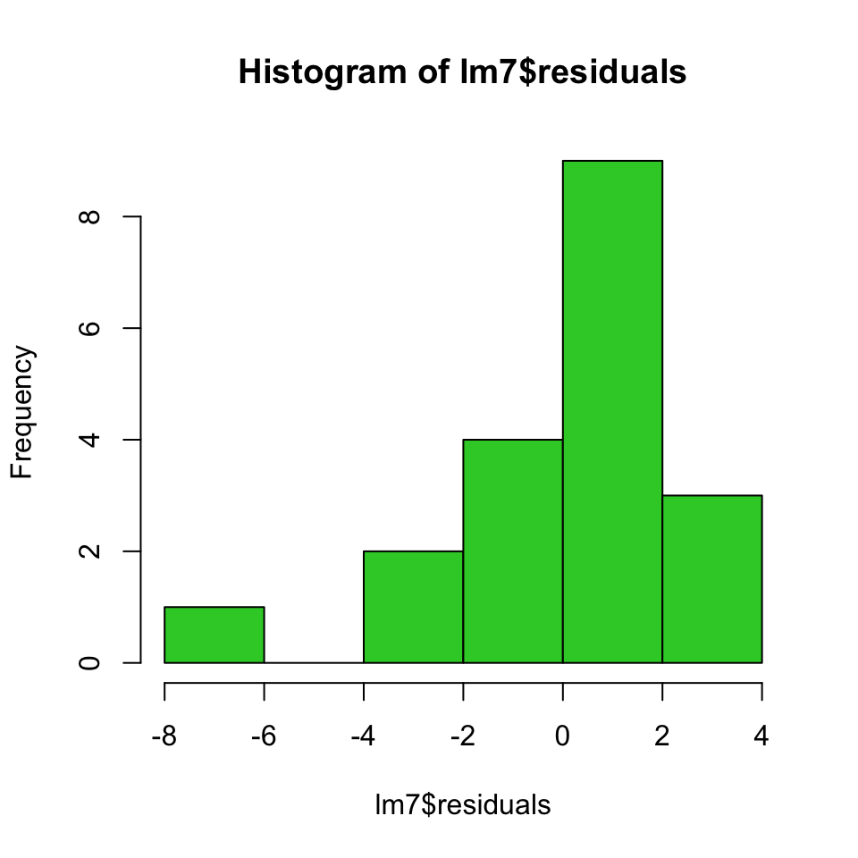

```r
gene1 = log2(edata[1,]+1)
lm7 = lm(gene1 ~ index)
hist(lm7$residuals,col=4)
```

Be careful when two variables in your regression model are very highly correlated. This is called co-linearity and can lead to highly variable and uninterpretable results. R fails “gracefully” (i.e. doesn’t tell you) when this happens so you have to check by hand. This is also a problem if you fit too many variables for example.

```r
lm8 = lm(gene1 ~ pdata$tissue.type + pdata$age)
tidy(lm8)
```

```
##                                 term    estimate std.error statistic
## 1                        (Intercept) 10.40407714       NaN       NaN
## 2           pdata$tissue.typeadrenal -2.64252590       NaN       NaN
## 3             pdata$tissue.typebrain -2.64918963       NaN       NaN
## 4            pdata$tissue.typebreast -0.55076758       NaN       NaN
## 5             pdata$tissue.typecolon -0.90025140       NaN       NaN
## 6             pdata$tissue.typeheart -3.42679721       NaN       NaN
## 7            pdata$tissue.typekidney -0.76564122       NaN       NaN
## 8             pdata$tissue.typeliver  0.52887576       NaN       NaN
## 9              pdata$tissue.typelung -0.73165179       NaN       NaN
## 10        pdata$tissue.typelymphnode -2.43829285       NaN       NaN
## 11            pdata$tissue.typeovary  0.09875467       NaN       NaN
## 12         pdata$tissue.typeprostate -0.79305234       NaN       NaN
## 13  pdata$tissue.typeskeletal_muscle -4.27479412       NaN       NaN
## 14           pdata$tissue.typetestes  0.47932985       NaN       NaN
```

[output cut: 19 more lines]

Another good idea is to look for “patterns” in the residuals

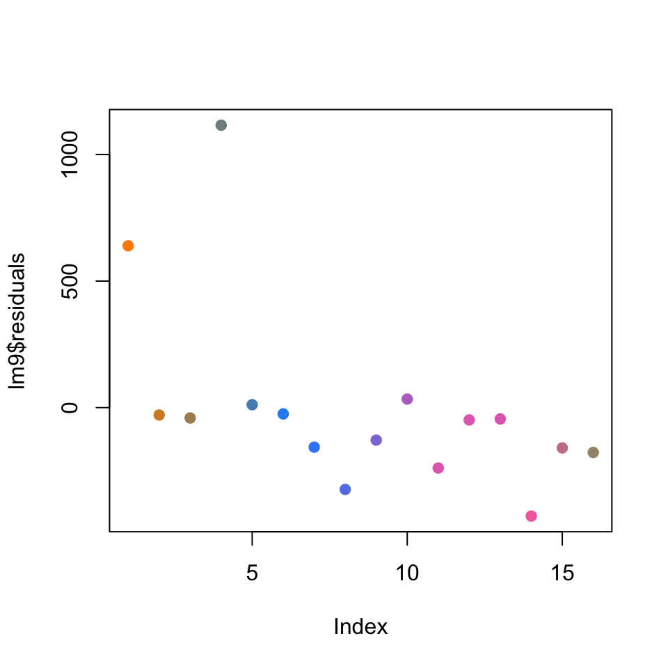

```r
colramp = colorRampPalette(1:4)(17)
lm9 = lm(edata[2,] ~ pdata$age)
plot(lm9$residuals,col=colramp[as.numeric(pdata$tissue.type)])
```

## Notes and further reading

This is of course a ridiculously brief introduction to linear models. The main thing to keep in mind is that you should visually inspect the model fits, consider the scale you are measuring on, and evaluate whether the covariates are related in ways that are normal to you. Here are some places to learn a lot more about linear models

- [Regression Models (Coursera)](https://www.coursera.org/course/regmods)
- [Introduction to linear models and matrix algebra (EdX)](http://online-learning.harvard.edu/course/introduction-linear-models-and-matrix-algebra)

## Session information

```
##  setting  value
##  version  R version 3.2.1 (2015-06-18)
##  system   x86_64, darwin10.8.0
##  ui       RStudio (0.99.447)
##  language (EN)
##  collate  en_US.UTF-8
##  tz       America/New_York
##
##  package           * version     date
##  acepack             1.3-3.3     2014-11-24
##  annotate            1.46.1      2015-07-11
##  AnnotationDbi     * 1.30.1      2015-04-26
##  assertthat          0.1         2013-12-06
##  BiasedUrn         * 1.06.1      2013-12-29
##  Biobase           * 2.28.0      2015-04-17
##  BiocGenerics      * 0.14.0      2015-04-17
##  BiocInstaller     * 1.18.4      2015-07-22
##  BiocParallel        1.2.20      2015-08-07
##  biomaRt             2.24.0      2015-04-17
##  Biostrings          2.36.3      2015-08-12
##  bitops              1.0-6       2013-08-17
##  bladderbatch      * 1.6.0       2015-08-26
##  broom             * 0.3.7       2015-05-06
##  caTools             1.17.1      2014-09-10
##  cluster             2.0.3       2015-07-21
##  colorspace          1.2-6       2015-03-11
##  corpcor             1.6.8       2015-07-08
##  curl                0.9.2       2015-08-08
##  DBI               * 0.3.1       2014-09-24
##  dendextend        * 1.1.0       2015-07-31
##  DESeq2            * 1.8.1       2015-05-02
##  devtools          * 1.8.0       2015-05-09
##  digest              0.6.8       2014-12-31
##  dplyr             * 0.4.3       2015-09-01
##  edge              * 2.1.0       2015-09-06
##  evaluate            0.7.2       2015-08-13
##  foreign             0.8-66      2015-08-19
##  formatR             1.2         2015-04-21
##  Formula           * 1.2-1       2015-04-07
##  futile.logger       1.4.1       2015-04-20
```

[output cut: 181 more lines]

```
##  Bioconductor
##  Bioconductor
##  CRAN (R 3.2.1)
##  CRAN (R 3.2.0)
##  CRAN (R 3.2.1)
##  Bioconductor
##  CRAN (R 3.2.0)
##  CRAN (R 3.2.2)
##  CRAN (R 3.2.0)
##  CRAN (R 3.2.1)
##  CRAN (R 3.2.2)
##  CRAN (R 3.2.0)
##  Bioconductor
##  CRAN (R 3.2.0)
##  Bioconductor
```

It is also useful to compile the time the document was processed. This document was processed on: 2015-09-06.